# HW 3 - Probability 1

Fatima Fairfax

9/7/2021

## Practice

First I will load tidyverse:

```r
library(tidyverse)
```

My friend is into poker and want to count cards and get rich quick. I will aid them. First checking a full deck of cards:

```r
deck <- tibble(
  card = rep(
    c("ace",
      "deuce",
      "three",
      "four",
      "five",
      "six",
      "seven",
      "eight",
      "nine",
      "ten",
      "jack",
      "queen",
      "king"
    ),4),
  suit =
    rep(c(
      "diamonds",
      "hearts",
      "clubs",
      "spades"),
        each = 13),
  color = rep(c("red",
                "black"),
              each = 26)
)

glimpse(deck)
```

```
## Rows: 52
## Columns: 3
## $ card  <chr> "ace", "deuce", "three", "four", "five", "six", "seven", "eight"…
## $ suit  <chr> "diamonds", "diamonds", "diamonds", "diamonds", "diamonds", "dia…
## $ color <chr> "red", "red", "red", "red", "red", "red", "red", "red", "red", "…
```

To find our the probability of getting a black card P(B) or an ace P(A), I can look at the following:

P(B U A) = P(B) + P(A) - P(B and A). To code this would look like:

```r
pr_black <- deck |>
  filter(color == "black") |>
  nrow() / nrow(deck)

pr_ace <- deck %>%
  filter(card == "ace") %>%
  nrow()/nrow(deck)

pr_black_and_ace <- deck %>%
  filter(card == "ace" & color == "black") %>%
  nrow()/nrow(deck)

pr_black + pr_ace - pr_black_and_ace
```

```
## [1] 0.5384615
```

##Question 1

The probability of getting one black card first *and* then one red card in two draws with replacement. This would be: P(B) * P(R), and red would be 1 - P(B):

```r
pr_black * (1 - (pr_black))
```

```
## [1] 0.25
```

The way to do this more data-wrangly would be to do the same thing to create a red probability:

```r
pr_red <- deck |>
  filter(color == "red") |>
  nrow() / nrow(deck)


pr_black * pr_red
```

```
## [1] 0.25
```

Then they ask the probability of getting one king *or* one ace in a single draw. This is P(king) + P(ace) - P(king and ace). The probability of king and ace though is 0. The probability of getting a king should be the same as getting an ace, but I will create a new variable for that:

```r
pr_king <- deck |>
  filter(card == "king") |>
  nrow() / nrow(deck)

pr_king + pr_ace
```

```
## [1] 0.1538462
```

Then the probability of getting two aces in two draws with replacement is ace^2:

```r
pr_ace^2
```

```
## [1] 0.00591716
```

##Question 2

Now my friend asks for some good poker hands of 5 cards without replacement. I’ll check what ?sample_n() does:

```r
?sample_n()
```

A random poker hand would look like:

```r
hand_1 <- deck |>
  sample_n(size = 5, replace = FALSE)

hand_1
```

```
## # A tibble: 5 × 3
##   card  suit     color
##   <chr> <chr>    <chr>
## 1 king  spades   black
## 2 jack  spades   black
## 3 eight diamonds red
## 4 five  spades   black
## 5 eight spades   black
```

Now, my friend (Bob is now their name) asks about the total number of different hands you can draw in poker. This could be answered using choose notation of 52 choose 5 = 52! / (52 - 5)!5!

In R, choose notation is: choose(k,n):

```r
possible_hands <- choose(k = 5, n= 52)
possible_hands
```

```
## [1] 2598960
```

There are 2,598,960 possible poker hands.

##Question 3

Bob now asks about the probability that each suit is represented in a hand. I.e., getting one card from each suit and one of the suits twice in a hand of 5

The probability of this could look like: P(any card) * P(any other suit out of the remaining 51) * P(any other but the first two suits out of the remaining 50) * P(the last suit out of the remaining 49) * P(any remaining card).

```r
every_suit_hand <- (52/52) * (39/51) * (26/50) * (13/49) * (48/48)
every_suit_hand
```

```
## [1] 0.1054982
```

##Question 4

```r
no_ace_hand <- (48/52) * (47/51) * (46/50) * (45/49) * (44/48)

at_least_one_ace <- 1 - no_ace_hand
at_least_one_ace
```

```
## [1] 0.341158
```

##Question 5

Now new friends ask for a favor trying to create committees for their company. There are 6 employees and they need a committee of 2. They want to know the possible combinations. Stackoverflow provides the following:

```r
df <- tibble(
  id   = 1:6,
  name = c('Alice', 'Bob', 'Charlie', 'Diane', 'Fred', 'Jenny')
)

df_pairs <- df %>%
  rename(id1 = id, name1 = name) %>%
  crossing(df %>%
             select(id2 = id, name2 = name)) %>%
  filter(id1 < id2) %>%
  unite(id, id1, id2) %>%
  unite(name, name1, name2)

df_pairs
```

```
## # A tibble: 15 × 2
##    id    name
##    <chr> <chr>
##  1 1_2   Alice_Bob
##  2 1_3   Alice_Charlie
##  3 1_4   Alice_Diane
##  4 1_5   Alice_Fred
##  5 1_6   Alice_Jenny
##  6 2_3   Bob_Charlie
##  7 2_4   Bob_Diane
##  8 2_5   Bob_Fred
##  9 2_6   Bob_Jenny
## 10 3_4   Charlie_Diane
## 11 3_5   Charlie_Fred
## 12 3_6   Charlie_Jenny
## 13 4_5   Diane_Fred
## 14 4_6   Diane_Jenny
## 15 5_6   Fred_Jenny
```

This is wordy, and hard to read.

I’m going to check what crossing and unite do:

```r
?crossing()
```

Crossing ‘de-duplicates’ and sorts inputs. This essentially creates two columns with the id and the names decoupled.

```r
?unite()
```

Unite pastes together multiple columns. This creates unique pairs seen in the id column (e.g., 1_2) and in the name column (e.g., Alice_Bob)

Now my friend wants an analytic solution to the question. I would use choose notation here as well. This would say, out of the 6 employees, how many combinations of 2 are there?

```r
cmtees <- choose(n = 6, k = 2)
cmtees
```

```
## [1] 15
```

This gives the same answer of 15 possible committees.

##Question 6:

Now the friend lets me know that there is a president and VP on each committee. Now we want every combination if the order of the pair does matter. First I’ll modify their code to produce this new list. To do this I will try to remove the filter that sorts out id1 < id2:

```r
df2 <- tibble(
  id   = 1:6,
  name = c('Alice', 'Bob', 'Charlie', 'Diane', 'Fred', 'Jenny')
)

df_pairs_PVP <- df2 %>%
  rename(id1 = id, name1 = name) %>%
  crossing(df2 %>%
             select(id2 = id, name2 = name)) %>%
  unite(id, id1, id2) %>%
  unite(name, name1, name2)

df_pairs_PVP
```

```
## # A tibble: 36 × 2
##    id    name
##    <chr> <chr>
##  1 1_1   Alice_Alice
##  2 1_2   Alice_Bob
##  3 1_3   Alice_Charlie
##  4 1_4   Alice_Diane
##  5 1_5   Alice_Fred
##  6 1_6   Alice_Jenny
##  7 2_1   Bob_Alice
##  8 2_2   Bob_Bob
##  9 2_3   Bob_Charlie
## 10 2_4   Bob_Diane
## # … with 26 more rows
```

This didn’t work because it gave me some duplicate pairs (e.g., Alice_Alice). So then I will add back a filter and specificy that it’s not equal:

```r
df2 <- tibble(
  id   = 1:6,
  name = c('Alice', 'Bob', 'Charlie', 'Diane', 'Fred', 'Jenny')
)

df_pairs_PVP <- df2 %>%
  rename(id1 = id, name1 = name) %>%
  crossing(df2 %>%
             select(id2 = id, name2 = name)) %>%
  filter(id1 != id2) |>
  unite(id, id1, id2) %>%
  unite(name, name1, name2)

df_pairs_PVP
```

```
## # A tibble: 30 × 2
##    id    name
##    <chr> <chr>
##  1 1_2   Alice_Bob
##  2 1_3   Alice_Charlie
##  3 1_4   Alice_Diane
##  4 1_5   Alice_Fred
##  5 1_6   Alice_Jenny
##  6 2_1   Bob_Alice
##  7 2_3   Bob_Charlie
##  8 2_4   Bob_Diane
##  9 2_5   Bob_Fred
## 10 2_6   Bob_Jenny
## # … with 20 more rows
```

This looks like it gives the right amount! Now we’re going to do this analytically (hopefully). To do this involves the permutations of this combination which would be n! / (n-k)!, which is 6! / (6 - 2)!:

```r
VPP_combos <- factorial(6) / factorial(4)
VPP_combos
```

```
## [1] 30
```

This gave me the same value!

##Question 7

Now looking at the sample function:

```r
?sample()
```

I am going to draw 1000 samples from 3 six-sided dice: (1) a fair die (2) a loaded die that lands of 6 50% of the time (3) a loaded die that lands on 5 with p = 1/3 and lands on 6 with p = 1/3.

Using ggplot I will show the values of the draws as well as the average for each die

First step is that I will build each of the die. To do this, I will create a die values vector and 3 probability vectors that correspond to the weights assigned:

```r
values <- c(1,2,3,4,5,6)

probs_die_1 <- c(1/6,
      1/6,
      1/6,
      1/6,
      1/6,
      1/6)

probs_die_2 <- c(1/6,
      1/6,
      1/12,
      1/12,
      0/6,
      3/6)

probs_die_3 <- c(1/12,
      1/12,
      1/12,
      1/12,
      2/6,
      2/6)
```

Now I will test the sample for die 1 for 1000 samples:

```r
set.seed(33)
sample_die_1 <- sample(x = values, size = 1000, replace = TRUE, prob = probs_die_1)
sample_die_1
```

[output not shown]

Now I will find the average and plot this in ggplot. First I will create a table that categorizes all of the values and counts. Then I will grab a simple average and then plot the new dataframe:

```r
set.seed(33)
d1 <- tibble(
    num = sample_die_1)

avg_die_1 <- mean(sample_die_1)
avg_die_1
```

```
## [1] 3.493
```

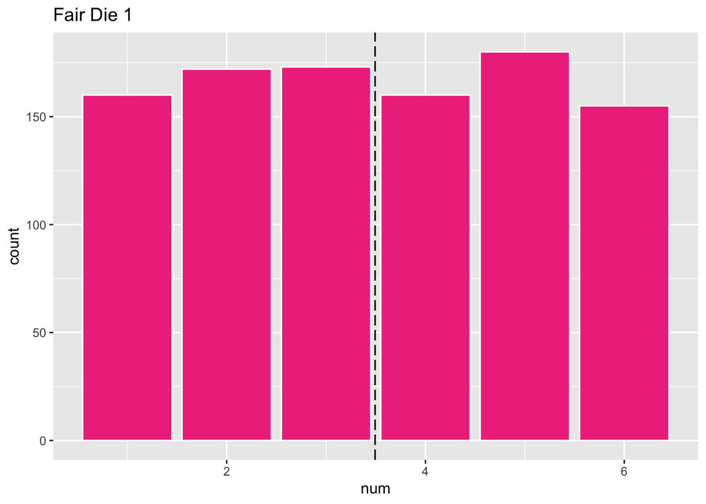

```r
ggplot(d1, mapping = aes(x = num)) +
  geom_bar(color = "white", fill = "violetred2") +
  labs(title = "Fair Die 1") +
  geom_vline(data = d1, aes(xintercept = mean(sample_die_1)), color = "black",linetype="longdash")
```

**I later learned how to add a line to show the average on the chart! I will now go back and add that as well as the average output for each of these graphs**

Okay! Now I will do the same for sample die 2:

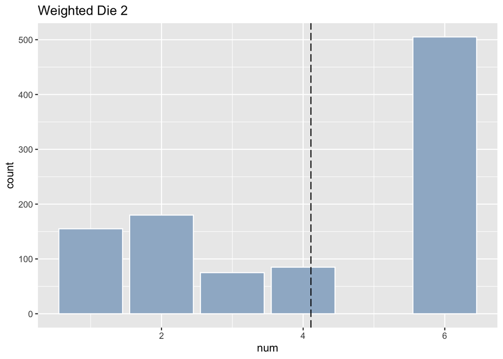

```r
set.seed(33)
sample_die_2 <- sample(x = values, size = 1000, replace = TRUE, prob = probs_die_2)

d2 <- tibble(
    num = sample_die_2)

ggplot(d2, mapping = aes(x = num)) +
  geom_bar(color = "white", fill = "slategray3") +
  labs(title = "Weighted Die 2") +
  geom_vline(data = d2, aes(xintercept = mean(sample_die_2)), color = "black",linetype="longdash")
```

```r
avg_die_2 <- mean(sample_die_2)
avg_die_2
```

```
## [1] 4.11
```

Now for Die 3, the same thing:

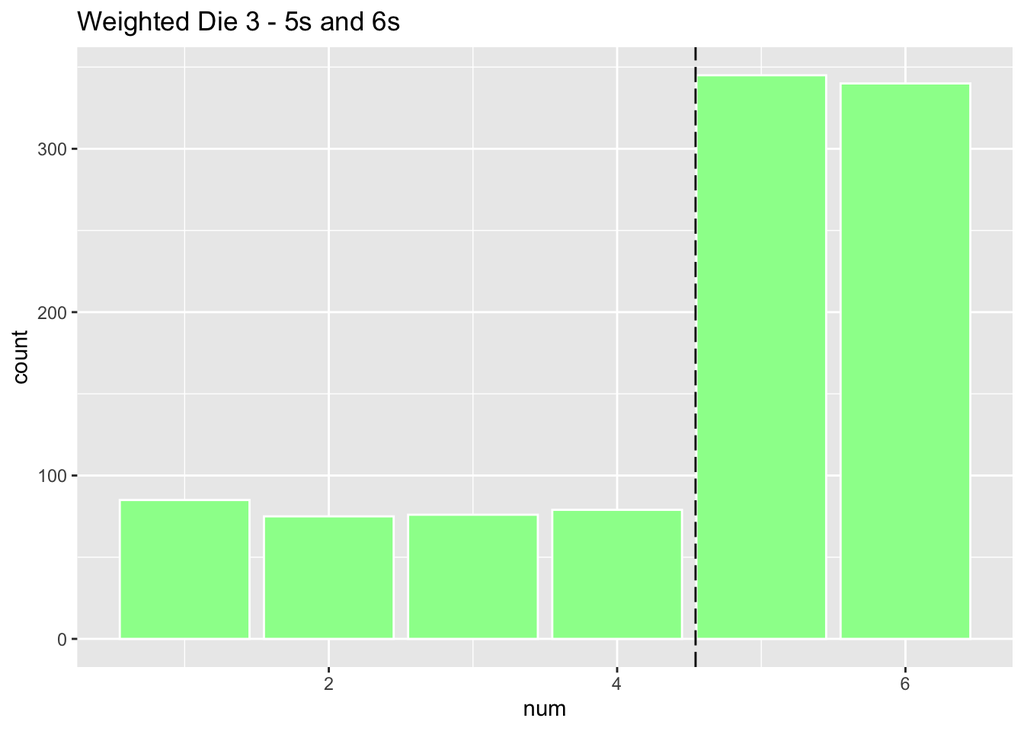

```r
set.seed(33)
sample_die_3 <- sample(x = values, size = 1000, replace = TRUE, prob = probs_die_3)

d3 <- tibble(
    num = sample_die_3)

ggplot(d3, mapping = aes(x = num)) +
  geom_bar(color = "white", fill = "palegreen1") +
  labs(title = "Weighted Die 3 - 5s and 6s") +
  geom_vline(data = d3, aes(xintercept = mean(sample_die_3)), color = "black",linetype="longdash")
```

```r
avg_die_3 <- mean(sample_die_3)
avg_die_3
```

```
## [1] 4.544
```